# Lab 3

Key

September 26, 2018

1. Run the following code to load the *tidyverse*.

```r
library(tidyverse)
```

1. Run the following lines of code to view and read about the data we’ll use for this lab.

```r
str(gss_cat)
View(gss_cat)
?gss_cat
```

2. Use `ggplot` to create a histogram of `tvhours`. The plot should:
- Include a small amount of transparency so gridlines are visible under the histogram.
- Be a different color than the default
- Include meaningful axis labels
- Have a title and a subtitle

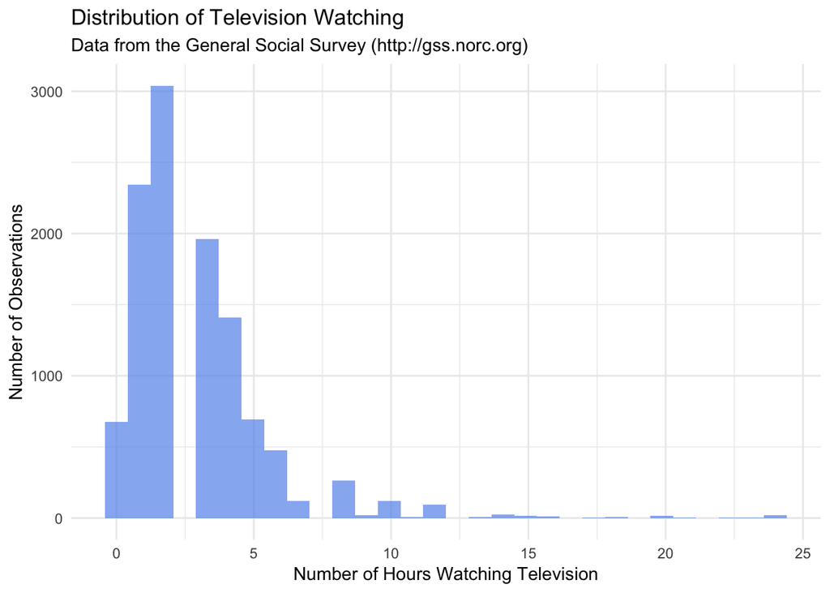

```r
theme_set(theme_minimal())
ggplot(gss_cat, aes(tvhours)) +
  geom_histogram(fill = "cornflowerblue",
                 alpha = 0.7) +
  labs(x = "Number of Hours Watching Television",
       y = "Number of Observations",
       title = "Distribution of Television Watching",
       subtitle = "Data from the General Social Survey (http://gss.norc.org)")
```

3. Create a ridgeline density plot of age by `partyid`. Do you notice any strong differences by party affiliation?

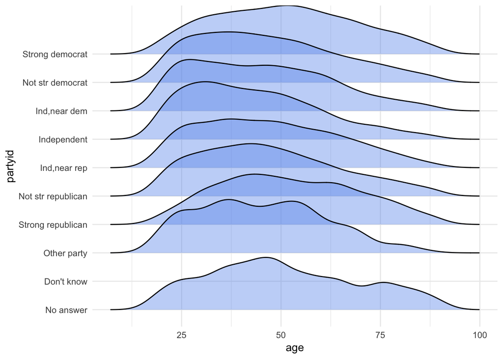

```r
library(ggridges)
ggplot(gss_cat, aes(age, partyid)) +
  geom_density_ridges(fill = "cornflowerblue", alpha = 0.4)
```

4. Modify the plot from Question 3 to produce separate densities by `race`. Do you see any patterns?

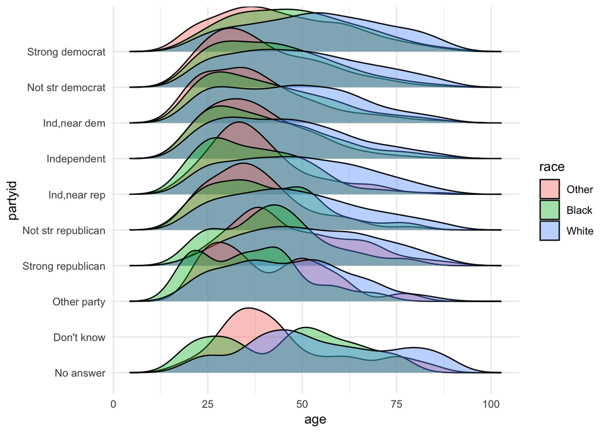

```r
ggplot(gss_cat, aes(age, partyid)) +
  geom_density_ridges(aes(fill = race), alpha = 0.4)
```

5. Replicate the plots from Questions 3 and 4, but this time displaying the relations with boxplots. Which do you think displays the relation more clearly? Why?

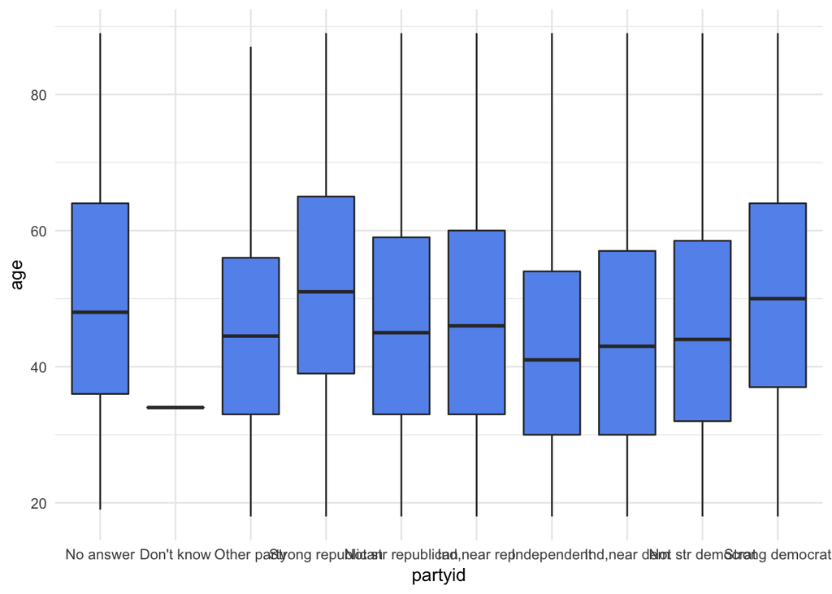

```r
ggplot(gss_cat, aes(partyid, age)) +
  geom_boxplot(fill = "cornflowerblue")
```

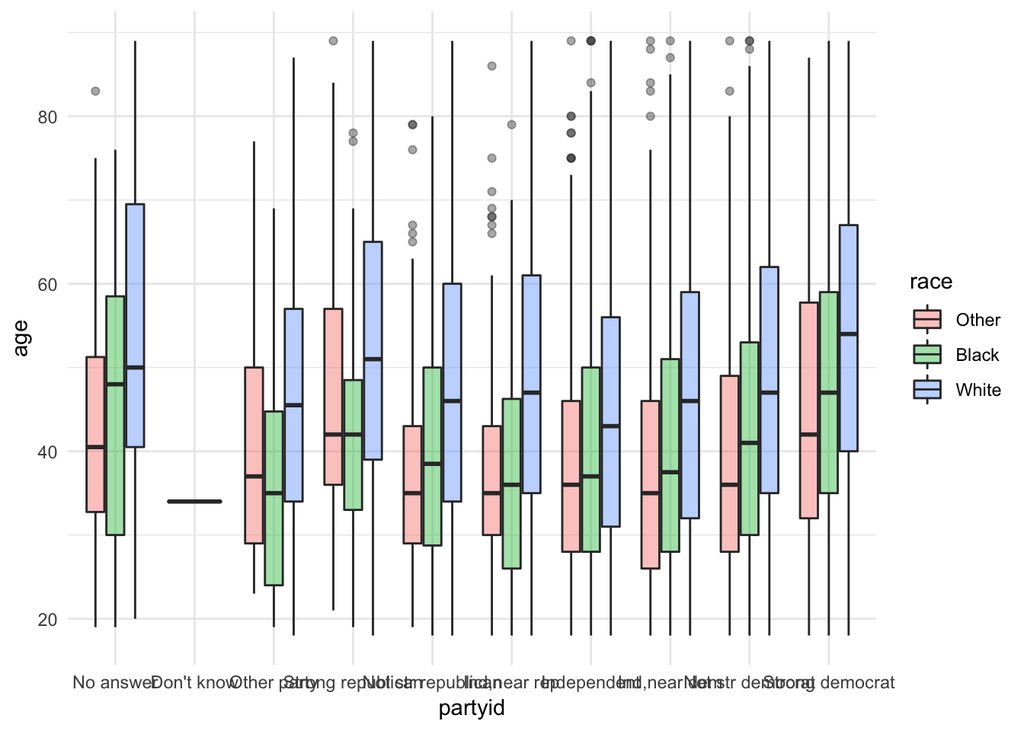

```r
ggplot(gss_cat, aes(partyid, age)) +
  geom_boxplot(aes(fill = race), alpha = 0.4)
```

6. Run the following lines of code to get a correlation matrix as a data frame.

```r
# install.packages(ISLR)
library(ISLR)
cor_tbl <- Hitters %>%
  select_if(is.numeric) %>%
  cor(use = "pairwise.complete.obs") %>%
  as.data.frame() %>%
  mutate(row = row.names(.)) %>%
  gather(col, cor, -row) %>%
  tbl_df()
```

Use the correlation table to create a heatmap using `geom_tile`. Change the colors to one of the four viridis palettes. What does the heatmap help you see?

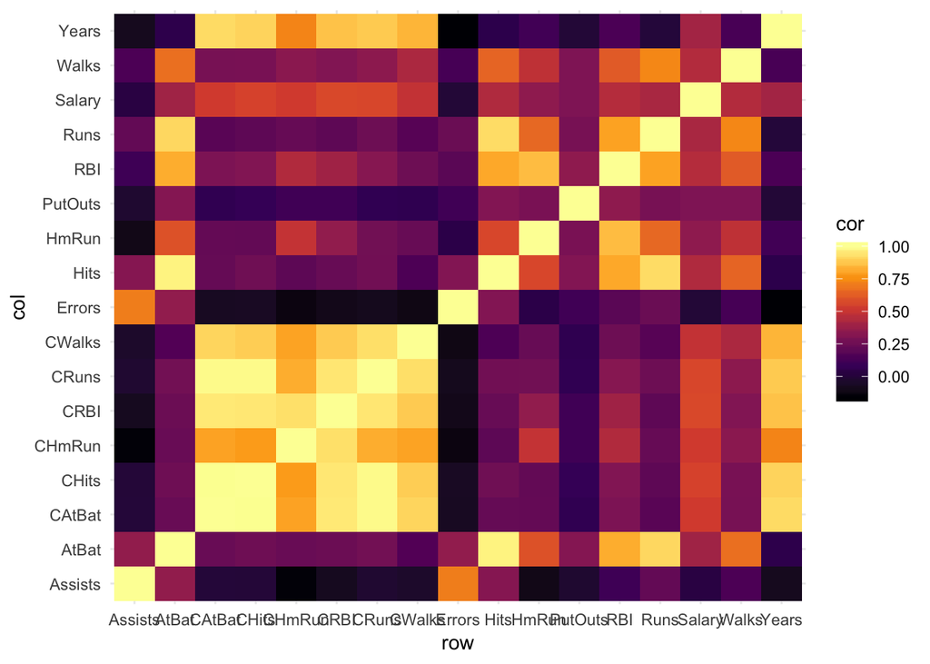

```r
ggplot(cor_tbl, aes(row, col, fill = cor)) +
  geom_tile() +
  scale_fill_viridis_c(option = "inferno")
```

7. The code below will produce a barplot.

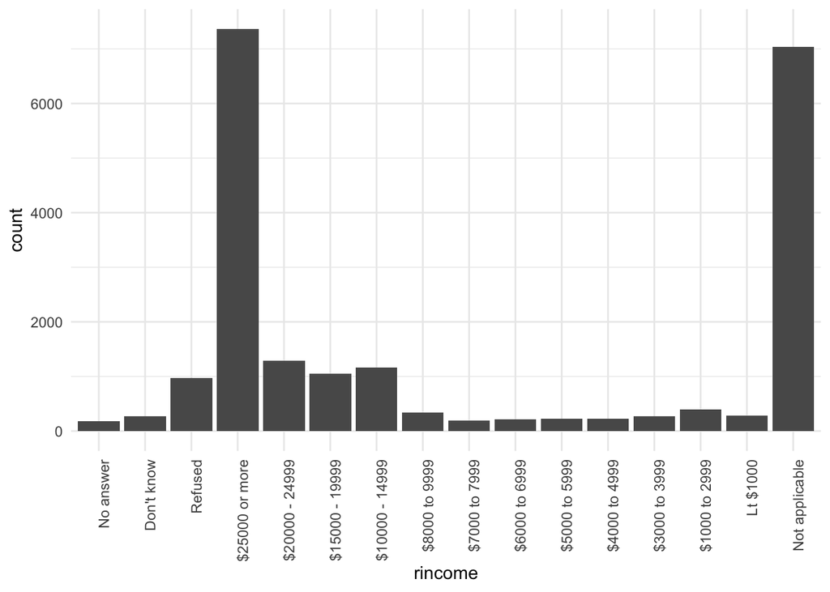

```r
ggplot(gss_cat, aes(rincome)) +
  geom_bar() +
  theme(axis.text.x = element_text(angle = 90, hjust = 1))
```

[figure not shown]